# hw-02-key

Your Name (S000000)

2026-11-08

```r
strava_runs <- read_csv("data/strava_runs.csv")
data_5k_10k <- strava_runs %>%
  mutate(
    event = case_when(
      distance..m. > 4998 & distance..m. < 5015  ~ "5k",
      distance..m. > 9998 & distance..m. < 10015 ~ "10k",
      TRUE ~ NA_character_
    )
  ) %>%
  filter(!is.na(event))
```

## Exercise 1

#### Question

The complete code snippet below produces a simple histogram of the average heart rate (in bpm) for male runners (“M”):

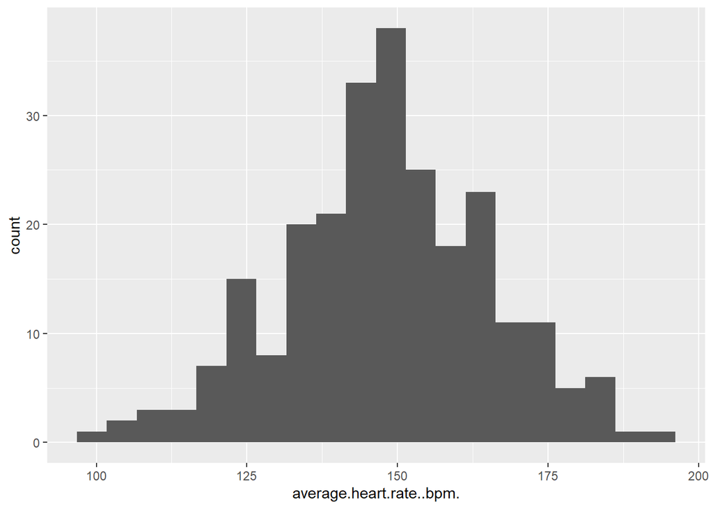

```r
data_5k_10k %>%
  filter(gender == "M") %>%
  filter(!is.na(average.heart.rate..bpm.)) %>%
  ggplot(aes(x = average.heart.rate..bpm.)) +
  geom_histogram(bins = 20)
```

- Describe the overall *shape* of the histogram. What does this suggest about the *structure* of the distribution of average heart rate among male runners? Calculate some simple summary statistics to support your comments.
- Create a similar data visualisation for female runners. Describe the *shape* of this histogram and discuss any similarities or differences between the male and female runners’ heart rate distributions.

#### Answer

###### 1(a)

```r
data_5k_10k %>%
  filter(gender == "M") %>%
  summarise(avg = mean(average.heart.rate..bpm., na.rm = TRUE),
            med = median(average.heart.rate..bpm., na.rm = TRUE),
            q25 = quantile(average.heart.rate..bpm., probs = 0.25, na.rm = TRUE),
            q75 = quantile(average.heart.rate..bpm., probs = 0.75, na.rm = TRUE),
            sd = sd(average.heart.rate..bpm., na.rm = TRUE),
            min = min(average.heart.rate..bpm., na.rm = TRUE),
            max = max(average.heart.rate..bpm., na.rm = TRUE))
```

```
## # A tibble: 1 × 7
##     avg   med   q25   q75    sd   min   max
##   <dbl> <dbl> <dbl> <dbl> <dbl> <dbl> <dbl>
## 1  148.  148.  138.  160.  17.2    97  191.
```

The histogram of average heart rate for male runners appears roughly *bell-shaped* and approximately *symmetric*, with most runners having an average heart rate between about 137 and 160 bpm (which are the two *quartiles* of the distribution), and a clear peak near 145 or 150 bpm. *Average* and *median* are approximately 148 bpm, further indicating symmetry. This shape suggests that the distribution of average heart rate among male runners follows an approximately normal distribution, with no strong skewness or outliers.

To visually assess the approximate normal distribution, we could overlay a normal distribution curve on the histogram, but this is not required for this exercise.

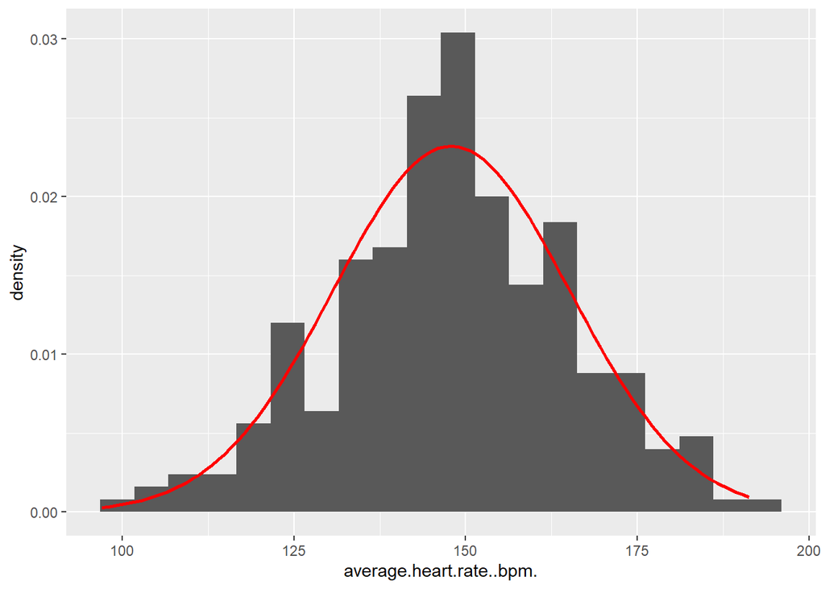

```r
data_5k_10k %>%
  filter(gender == "M") %>%
  filter(!is.na(average.heart.rate..bpm.)) %>%
  ggplot(aes(x = average.heart.rate..bpm.)) +
  geom_histogram(aes(y = after_stat(density)),bins = 20)+
  stat_function(fun = dnorm,
                args = list(mean = 147.9, # using values estimated from summary
                            sd = 17.2),   # using values estimated from summary
                color = "red", linewidth = 1)
```

A smaller mode could be identified around 120 bpm, suggesting a small number of runners with lower average heart rates, but this is not a strong feature of the distribution.

###### 1(b)

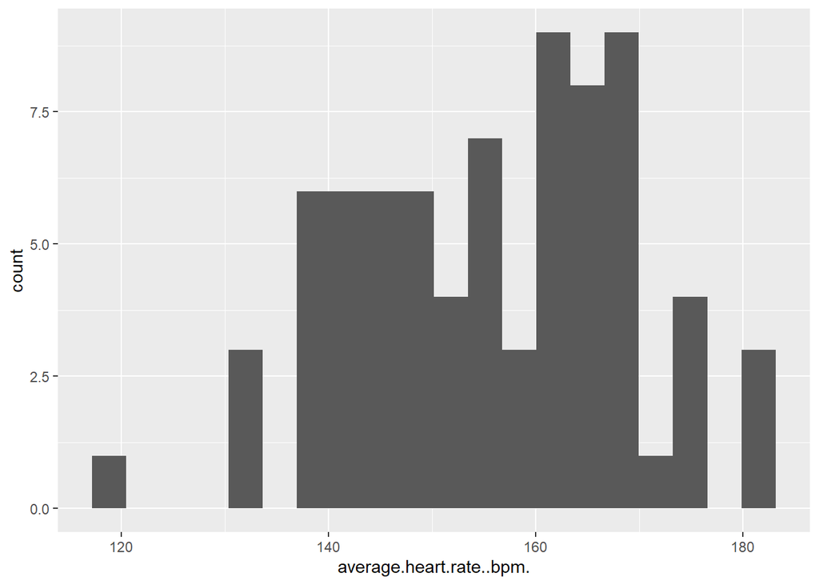

```r
data_5k_10k %>%
  filter(gender == "F") %>%
  filter(!is.na(average.heart.rate..bpm.)) %>%
  ggplot(aes(x = average.heart.rate..bpm.)) +
  geom_histogram(bins = 20)
```

The histogram of average heart rate among female runners shows a *bimodal* distribution, with two noticeable *peaks* — one around 145/150 bpm and another near 165 bpm. This suggests that there may be two subgroups of runs with different typical heart rate levels, possibly reflecting differences in fitness level, pacing, elevation, or race distance.

```r
data_5k_10k %>%
  filter(gender == "F") %>%
  summarise(avg = mean(average.heart.rate..bpm., na.rm = TRUE),
            med = median(average.heart.rate..bpm., na.rm = TRUE),
            q25 = quantile(average.heart.rate..bpm., probs = 0.25, na.rm = TRUE),
            q75 = quantile(average.heart.rate..bpm., probs = 0.75, na.rm = TRUE),
            sd = sd(average.heart.rate..bpm., na.rm = TRUE),
            min = min(average.heart.rate..bpm., na.rm = TRUE),
            max = max(average.heart.rate..bpm., na.rm = TRUE))
```

```
## # A tibble: 1 × 7
##     avg   med   q25   q75    sd   min   max
##   <dbl> <dbl> <dbl> <dbl> <dbl> <dbl> <dbl>
## 1  156.  157.  146.  166.  13.2  120.  182.
```

## Exercise 2

#### Question

Create a data visualisation based on the description.

> Make a sequence of boxplots for the pace (in minutes per kilometer) achieved in 5K and 10K runs. The boxplots should be orientated vertically (i.e. side-by-side) based on the run’s length (5K vs 10K). Furthermore, the data visualisation should consist of two panels for the two different genders the runners identify with, with shared axes. Finally, add appropriate text to the image in order to assist the reader in understanding the data visualisation.

Provide a brief comment about the relationships seen in the data visualisation created by the above description.

#### Answer

The data visualisation was generated using the following code:

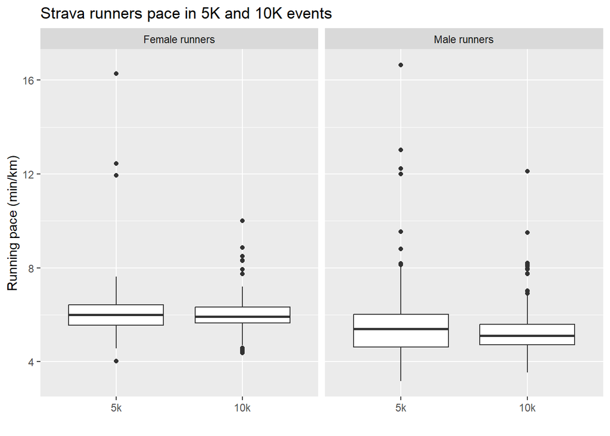

```r
data_5k_10k %>%
  filter(!is.na(gender)) %>%
  mutate(
    pace_minkm = elapsed.time..s./60/(distance..m./1000),
    gender = case_when(
     gender == "M" ~ "Male runners",
     gender == "F" ~ "Female runners"
   ),
   event = fct_relevel(event, "5k", "10k")
  ) %>%
  ggplot(aes(x = event, y = pace_minkm)) +
  geom_boxplot() +
  facet_wrap(~gender)+
  labs(
     x = "",
     y = "Running pace (min/km)",
     title = "Strava runners pace in 5K and 10K events"
  )
```

Note that it is possible to obtain the same data visualisation via some variation in coding for the filtering, mutating and graphical layers. Where appropriate, credit will be awarded where the code is constructive towards the re-creation of the data visualisation.

**Comment**: The pace for the 5K and 10K events are very similar for female runners, with similar median and spread of the data, even though the 5K events display more extreme outliers. For male runners, the median pace are also similar for 5K and 10K events, but the spread of the data for the 5K event is noticeably larger than that for the 10K event.

## Exercise 3

#### Answer

First, we identify long-distance and short-distance runners. By merging (with `left_join`) we only include runs from athletes that are classified as either long-distance or short-distance runners.

```r
strava_runs <- strava_runs %>%
  mutate(distance_km = distance..m./1000,
         speed_ms = distance..m./elapsed.time..s.)

runs_long_vs_short <- strava_runs %>%
  group_by(athlete) %>%
  summarise(
    avg_dist = mean(distance_km, na.rm = TRUE)
  ) %>%
  mutate(
    long_runner = case_when(
      avg_dist > 13 ~ TRUE,
      avg_dist < 7  ~ FALSE,
      TRUE          ~ NA
    )
  ) %>%
  filter(!is.na(long_runner)) %>%
  select(athlete, long_runner) %>%
  left_join(strava_runs, by = "athlete")
```

We now reproduce the image:

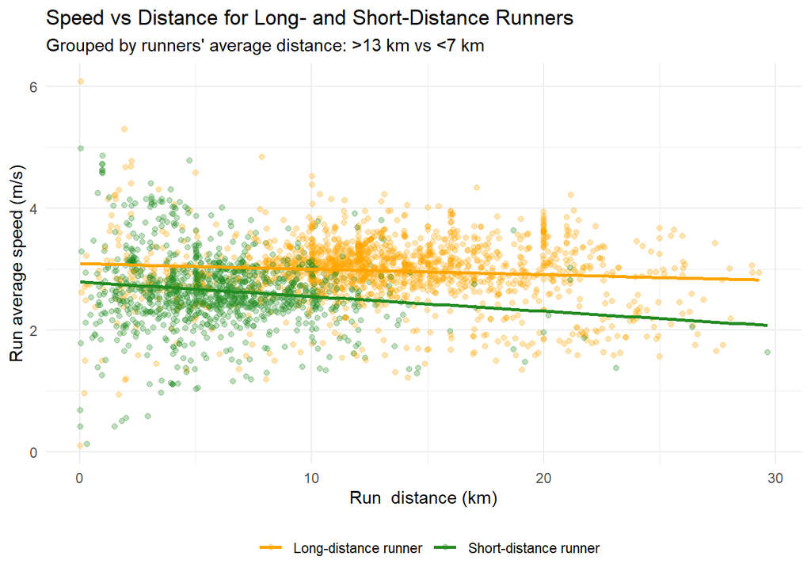

```r
runs_long_vs_short %>%
  mutate(
    runner = case_when(
      long_runner == TRUE ~ "Long-distance runner",
      long_runner == FALSE ~ "Short-distance runner")) %>%
  ggplot(mapping = aes(x = distance_km,
                     y = speed_ms,
                     colour = runner))+
  geom_point(alpha = 0.3) +
  geom_smooth(method = "lm", se = FALSE) +
   scale_colour_manual(values = c(
     "Long-distance runner" = "orange",
     "Short-distance runner" = "forestgreen")) +
   theme_minimal() +
   theme(legend.position = "bottom") +
   labs(
     x = "Run  distance (km)",
     y = "Run average speed (m/s)",
     title = "Speed vs Distance for Long- and Short-Distance Runners",
     subtitle = "Grouped by runners' average distance: >13 km vs <7 km",
     colour = ""
   )
```

**Comment**: This visualization demonstrates that runners who are, on average, short-distance runners tend to have lower speeds compared to long-distance runners. As short-distance runners increase their run distance, their speed decreases more sharply, whereas long-distance runners tend to maintain a more constant speed across a wider range of distances.

## Exercise 4

#### Question

Now the goal is to compare male and female runners based on average values after removing all missing values in the gender variable.

1. For each gender, calculate the mean distance (in km), and the mean elapsed time (in minutes). Create two side-by-side bar charts: one showing the mean distance and one showing the mean elapsed time for each gender. The bars should filled with different colors based on the gender information. (**3 pts**)
2. Provide a brief comment about what you have seen in the mean distance and elapsed time for each gender. (**2 pts**)

#### Answer

First we need to get related mean values based on `distance..m.` and `elapsed.time..s.` by suitable transformation, from meters to km and seconds to minutes respectively. For the practical purposes, we can apply pivot_longer() to use later the same data frame in a new format for data viz. While faceting with geom_col() function to create bar charts, scales = “free_y” is essential since the two measures are in different units (km vs minutes), so a shared axis would distort the comparison.

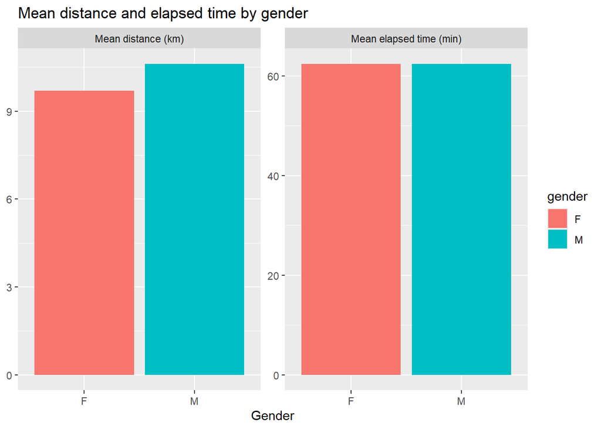

```r
gender_summary <- strava_runs %>%
  filter(!is.na(gender)) %>%
  group_by(gender) %>%
  summarise(
    mean_dist_km  = mean(distance..m. / 1000, na.rm = TRUE),
    mean_time_min = mean(elapsed.time..s. / 60, na.rm = TRUE)
  )

gender_summary <- gender_summary %>%
  pivot_longer(
    cols = c(mean_dist_km, mean_time_min),
    names_to = "measure",
    values_to = "value"
  )

gender_summary %>%
  ggplot(aes(x = gender, y = value, fill = gender)) +
  geom_col() +
  facet_wrap(~ measure, scales = "free_y",
             labeller = as_labeller(c(mean_dist_km  = "Mean distance (km)",
                                      mean_time_min = "Mean elapsed time (min)"))) +
  labs(x = "Gender", y = NULL,
       title = "Mean distance and elapsed time by gender")
```

The other option could be creating both bar charts separately and combine with the patchwork package in R. This does not require the pivoting step.

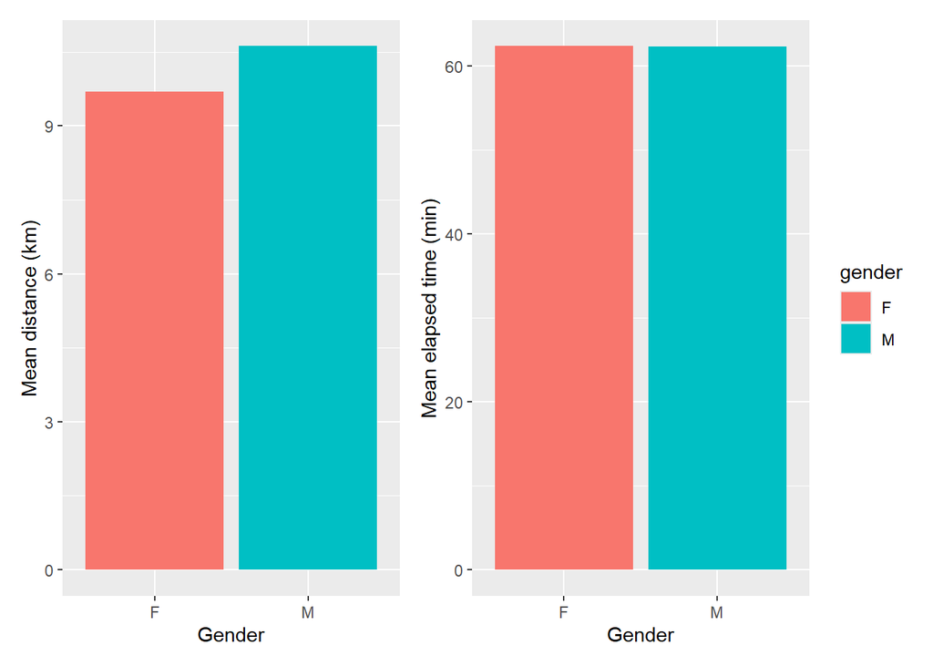

```r
library(patchwork)

gender_summary <- strava_runs %>%
  filter(!is.na(gender)) %>%
  group_by(gender) %>%
  summarise(
    mean_dist_km  = mean(distance..m. / 1000, na.rm = TRUE),
    mean_time_min = mean(elapsed.time..s. / 60, na.rm = TRUE)
  )

p_dist <- ggplot(gender_summary, aes(x = gender, y = mean_dist_km, fill = gender)) +
  geom_col() +
  labs(x = "Gender", y = "Mean distance (km)") +
  theme(legend.position =  "none") # without this part, it duplicates legend info

p_time <- ggplot(gender_summary, aes(x = gender, y = mean_time_min, fill = gender)) +
  geom_col() +
  labs(x = "Gender", y = "Mean elapsed time (min)")

p_dist + p_time
```

**Comment**: Overall there is two distinct comment on the male vs female runners. The mean distance for male runners is slightly higher than the female runners on the left panel. The mean elapsed time seems not different for male and female runners on the right panel, that indicates, in the same average elapsed time, the male runner covered slightly higher distance than female runners. This can be supported by referring to these numerical values.

```r
gender_summary
```

```
## # A tibble: 2 × 3
##   gender mean_dist_km mean_time_min
##   <chr>         <dbl>         <dbl>
## 1 F              9.70          62.4
## 2 M             10.6           62.4
```